# 1강. 데이터 분석 환경과 기본 개념

- 첫째마당 (01-03)
- pp.014-073 (60쪽)

# 01. 안녕, 파이썬?

## 01-1. 데이터 분석과 파이썬(19-25쪽)

- 파이썬 사용처 : 통계 분석, 머신러닝 모델링, 텍스트 마이닝, 네트워크 분석, 지도 시각화, 주식 분석, 이미지 분석, 사운드 분석, 소프트웨어 개발
- 2022년 1월 현재, 프로그래밍 언어 중 1위

## 01-2. 파이썬이 강력한 데이터 분석 도구인 이유(26-30쪽)

- 오픈 소스 ..., 다양한 그래프 작성
- '프로그래밍 방식' : 재현성 확보, 오류 방지, 공동 작업에 편리

# 02. 파이썬 데이터 분석 환경 만들기

## 02-1. 아나콘다로 파이썬과 JupyterLab 설치하기(32-36쪽)

- PC에 파이썬, JupyterLab 설치
  - JupyterLab : 데이터 분석 작업을 쉽게 할 수 있게 도와주는 IDE 소프트웨어
  - IDE : Integrated Development Environment, 통합개발환경

### [Do it! 실습] 아나콘다 다운로드 및 설치하기(32쪽)

### [Do it! 실습] 프롬프트에서 파이썬 사용해보기(34쪽)

## 02-2. JupyterLab과 친해지기(37-47쪽)

### [Do it! 실습] JupyterLab 실행하기(37쪽)

### [Do it! 실습] 노트북 다루기(39쪽)

### [Do it! 실습] 노트북 저장하기, 노트북 열기(43쪽)

### [Do it! 실습] 워킹 디렉토리 다루기(45쪽)

## 02-3. 유용한 환경 설정(48-50쪽)

### [Do it! 실습] 보기 좋게 화면 조절하기(48쪽)

### [Do it! 실습] JupyterLab 실행 파일 만들기(49쪽)

### [Do it! 실습] JupyterLab 바로 가기 만들기(50쪽)

### 3장을 위한 준비(51쪽)

```python
# excel_exam.xlsx 다운로드
# 관련 데이터 다운로드(깃헙) : https://github.com/youngwoos/Doit_Python
```

```python
df_exam = pd.read_excel('excel_exam.xlsx') # 엑셀 파일을 불러와 df_exam에 할당
df_exam                                    # 출력
```

|  | id | nclass | math | english | science |
| --- | --- | --- | --- | --- | --- |
| 0 | 1 | 1 | 50 | 98 | 50 |
| 1 | 2 | 1 | 60 | 97 | 60 |
| 2 | 3 | 1 | 45 | 86 | 78 |
| 3 | 4 | 1 | 30 | 98 | 58 |
| 4 | 5 | 2 | 25 | 80 | 65 |
| 5 | 6 | 2 | 50 | 89 | 98 |
| 6 | 7 | 2 | 80 | 90 | 45 |
| 7 | 8 | 2 | 90 | 78 | 25 |
| 8 | 9 | 3 | 20 | 98 | 15 |
| 9 | 10 | 3 | 50 | 98 | 45 |
| 10 | 11 | 3 | 65 | 65 | 65 |
| 11 | 12 | 3 | 45 | 85 | 32 |
| 12 | 13 | 4 | 46 | 98 | 65 |
| 13 | 14 | 4 | 48 | 87 | 12 |
| 14 | 15 | 4 | 75 | 56 | 78 |
| 15 | 16 | 4 | 58 | 98 | 65 |
| 16 | 17 | 5 | 65 | 68 | 98 |
| 17 | 18 | 5 | 80 | 78 | 90 |
| 18 | 19 | 5 | 89 | 68 | 87 |
| 19 | 20 | 5 | 78 | 83 | 58 |

# 03. 데이터 분석에 필요한 연장 챙기기

## 03-1. 변하는 수, '변수' 이해하기(53-58쪽)

- 변수 : '변하는 수'. 다양한 값을 지닌 하나의 속성 -> 데이터는 변수들의 덩어리.
- 변수는 데이터 분석의 '대상'이다.
- 데이터 분석 : 변수 간의 관계를 파악하는 작업.

### [Do it! 실습] 변수 만들기(54쪽)

```python
a = 1
a
```

```
1
```

```python
b = 2
b
```

```
2
```

```python
c = 3
c
```

```
3
```

```python
d = 3.5
d
```

```
3.5
```

```python
a + b
```

```
3
```

```python
a + b + c
```

```
6
```

```python
4 / b
```

```
2.0
```

```python
5 * b
```

```
10
```

```python
# 변수명 정하기 규칙(55쪽) - 문자로 시작, 영문 권장, 소문자
```

### [Do it! 실습] 여러 값으로 구성된 변수 만들기(56쪽)

```python
var1 = [1, 2, 3]
var1
```

```
[1, 2, 3]
```

```python
var2 = [4, 5, 6]
var2
```

```
[4, 5, 6]
```

```python
var1 + var2
```

```
[1, 2, 3, 4, 5, 6]
```

### [Do it! 실습] 문자로 된 변수 만들기(57쪽)

```python
str1 = 'a'
str1
```

```
'a'
```

```python
str2 = 'text'
str2
```

```
'text'
```

```python
str3 = 'Hello World!'
str3
```

```
'Hello World!'
```

```python
str4 = ['a', 'b', 'c']
str4
```

```
['a', 'b', 'c']
```

```python
str5 = ['Hello', 'World', 'is', 'good']
str5
```

```
['Hello', 'World', 'is', 'good']
```

```python
str2 + str3
```

```
'textHello World!'
```

```python
str2 + ' ' + str3
```

```
'text Hello World!'
```

```python
# 문자로 된 변수로는 연산할 수 없다.
str1 + 2
```

```
---------------------------------------------------------------------------
TypeError                                 Traceback (most recent call last)
Cell In[83], line 2
      1 # 문자로 된 변수로는 연산할 수 없다.
----> 2 str1 + 2

TypeError: can only concatenate str (not "int") to str
```

## 03-2. 마술 상자 같은 '함수' 이해하기(59-61쪽)

- 데이터 분석은 '함수를 이용해서 변수를 조작하는 일'이다.
- 함수 : 입력값에 특정 기능을 수행하여 처음과 다른 값을 산출

### [Do it! 실습] 함수 이용하기(60쪽)

- 함수 : 함수 이름 + 괄호
- 함수 =:= 특정 기능을 하는 상자

```python
# 변수 만들기
x = [1, 2, 3]
x
```

```
[1, 2, 3]
```

```python
# 함수 적용하기
sum(x)
```

```
6
```

```python
# 최대값
max(x)
```

```
3
```

```python
# 최소값
min(x)
```

```
1
```

```python
# 함수의 결과물로 새 변수 만들기

x_sum = sum(x)
x_sum
```

```
6
```

```python
x_max = max(x)
x_max
```

```
3
```

## 03-3. 함수 꾸러미, '패키지' 이해하기(62-73쪽)

- 패키지 =:= 함수가 여러 개 들어 있는 꾸러미

### [Do it! 실습] 패키지 활용하기(63쪽)

- 패키지 사용하려면, 패키지를 설치한 다음 로드해야 함.
- 패키지 설치는 한 번만 하면 됨. But 로드는 JupyterLab 새로 시작할 때마다 반복해야 함.
- 아나콘다에는 주요 패키지가 대부분 들어 있다.

#### 패키지 함수 사용하기

- seaborn 패키지의 countplot() 함수 -> 빈도 막대 그래프 작성

```python
import seaborn  # 패키지 로드
```

```python
var = ['a', 'a', 'b', 'c']
var
```

```
['a', 'a', 'b', 'c']
```

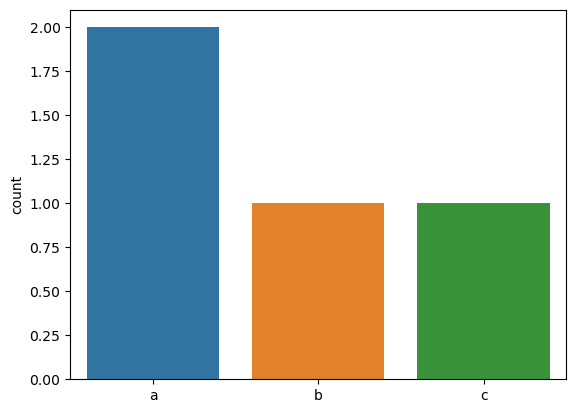

```python
seaborn.countplot(x = var)
```

#### 설치하거나 로드하지 않고 사용하는 내장함수

- sum() max() min() 등

#### 패키지 약어 활용하기

```python
import seaborn as sns
```

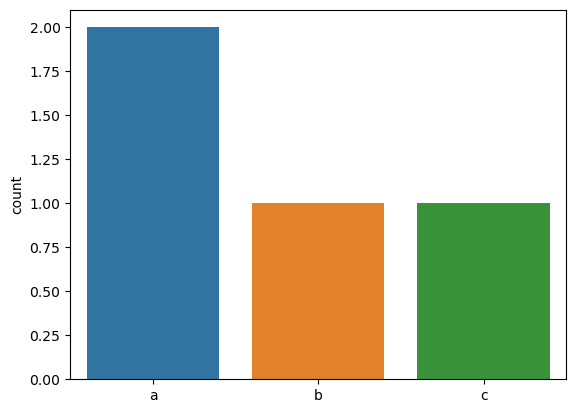

```python
sns.countplot(x = var)
```

### [Do it! 실습] seaborn의 titanic 데이터로 그래프 만들기(66쪽)

- seabron 패키지의 dataload_dataset()를 이용하면 seaborn 패키지에 들어 있는 데이터를 불러올 수 있음.
- titanic 데이터

```python
df = sns.load_dataset('titanic')
df
```

|  | survived | pclass | sex | age | sibsp | parch | fare | embarked | class | who | adult_male | deck | embark_town | alive | alone |
| --- | --- | --- | --- | --- | --- | --- | --- | --- | --- | --- | --- | --- | --- | --- | --- |
| 0 | 0 | 3 | male | 22.0 | 1 | 0 | 7.2500 | S | Third | man | True | NaN | Southampton | no | False |
| 1 | 1 | 1 | female | 38.0 | 1 | 0 | 71.2833 | C | First | woman | False | C | Cherbourg | yes | False |
| 2 | 1 | 3 | female | 26.0 | 0 | 0 | 7.9250 | S | Third | woman | False | NaN | Southampton | yes | True |
| 3 | 1 | 1 | female | 35.0 | 1 | 0 | 53.1000 | S | First | woman | False | C | Southampton | yes | False |
| 4 | 0 | 3 | male | 35.0 | 0 | 0 | 8.0500 | S | Third | man | True | NaN | Southampton | no | True |
| ... | ... | ... | ... | ... | ... | ... | ... | ... | ... | ... | ... | ... | ... | ... | ... |
| 886 | 0 | 2 | male | 27.0 | 0 | 0 | 13.0000 | S | Second | man | True | NaN | Southampton | no | True |
| 887 | 1 | 1 | female | 19.0 | 0 | 0 | 30.0000 | S | First | woman | False | B | Southampton | yes | True |
| 888 | 0 | 3 | female | NaN | 1 | 2 | 23.4500 | S | Third | woman | False | NaN | Southampton | no | False |
| 889 | 1 | 1 | male | 26.0 | 0 | 0 | 30.0000 | C | First | man | True | C | Cherbourg | yes | True |
| 890 | 0 | 3 | male | 32.0 | 0 | 0 | 7.7500 | Q | Third | man | True | NaN | Queenstown | no | True |

891 rows × 15 columns

### 함수의 다양한 기능 이용하기(66쪽)

- 파라미터(매개변수) : 함수의 옵션을 설정하는 명령어.  
  ex) countplot()에 입력한 'x'

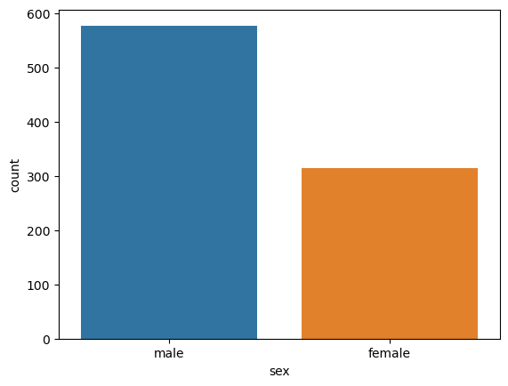

```python
sns.countplot(data = df, x='sex')
```

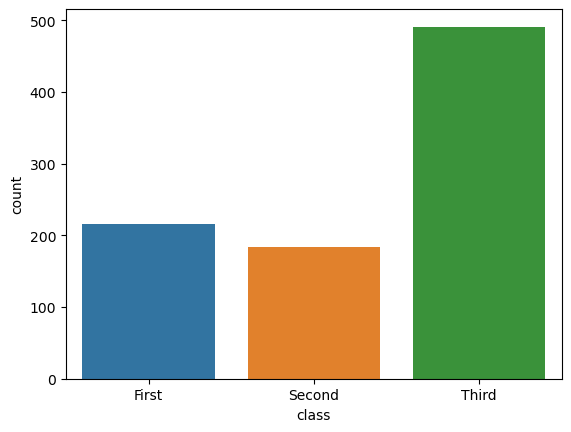

```python
sns.countplot(data = df, x='class')
```

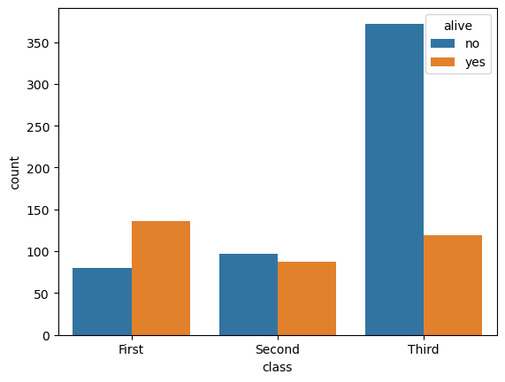

```python
sns.countplot(data = df, x='class', hue='alive') # x축 class
# hue : 변수 항목별로 막대의 색을 다르게 표현하는 파라미터
```

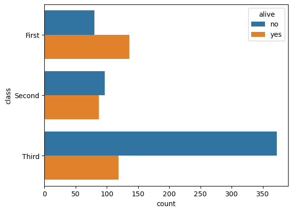

```python
sns.countplot(data = df, y='class', hue='alive') # y축 class
# hue : 변수 항목별로 막대의 색을 다르게 표현하는 파라미터
```

[용어/ChatGPT] "Hue"라는 단어의 어원

- 주로 색상과 관련된 의미로 사용되며, 이는 중세 영어 "hew"라는 단어에서 파생
- 고대 영어의 "hiw"나 "hīw"에서 온 것으로, "외모", "모양", 또는 "색상"을 의미
- 시간이 지나면서 이 단어는 주로 색상을 나타내는 데 사용.
- Hue Saturation Lightness (HSL): 이는 색상 모델의 한 형태로, 색상(hue), 채도(saturation), 밝기(lightness)의 세 가지 기본 요소를 사용하여 색상을 정의

### 함수 사용법 궁금할 때 : Help 함수 활용(68쪽)

```python
# sns.countplot() 매뉴얼 출력
sns.countplot?
```

```
Signature:
sns.countplot(
    data=None,
    *,
    x=None,
    y=None,
    hue=None,
    order=None,
    hue_order=None,
    orient=None,
    color=None,
    palette=None,
    saturation=0.75,
    width=0.8,
    dodge=True,
    ax=None,
    **kwargs,
)
Docstring:
Show the counts of observations in each categorical bin using bars.

A count plot can be thought of as a histogram across a categorical, instead
of quantitative, variable. The basic API and options are identical to those
for :func:`barplot`, so you can compare counts across nested variables.

Note that the newer :func:`histplot` function offers more functionality, although
its default behavior is somewhat different.

.. note::
    This function always treats one of the variables as categorical and
    draws data at ordinal positions (0, 1, ... n) on the relevant axis,
    even when the data has a numeric or date type.

See the :ref:`tutorial <categorical_tutorial>` for more information.

Parameters
----------
data : DataFrame, array, or list of arrays, optional
    Dataset for plotting. If ``x`` and ``y`` are absent, this is
    interpreted as wide-form. Otherwise it is expected to be long-form.
```

[output cut: 30 more lines]

```
-------
ax : matplotlib Axes
    Returns the Axes object with the plot drawn onto it.

See Also
--------
barplot : Show point estimates and confidence intervals using bars.
catplot : Combine a categorical plot with a :class:`FacetGrid`.

Examples
--------

.. include:: ../docstrings/countplot.rst
File:      c:\users\tokyo\anaconda3\lib\site-packages\seaborn\categorical.py
Type:      function
```

### 모듈 알아 보기(69쪽)

- 모듈 : 비슷한 함수끼리 묶은 것
- 패키지라는 큰 꾸러미 속에, 모듈이라는 작은 꾸러미가 있는 모양
- [함수, 모듈, 패키지의 차이점](https://onesixx.com/%ED%95%A8%EC%88%98-%EB%AA%A8%EB%93%88-%ED%8C%A8%ED%82%A4%EC%A7%80%EC%9D%98-%EC%B0%A8%EC%9D%B4%EC%A0%90/)

```python
# sklearn 패키지의 metrics 모듈 로드하기
import sklearn.metrics
```

```python
# sklearn 패키지 metrics 모듈의 accuracy_score() 함수 사용하기
sklearn.metrics.accuracy_score() # 일단 여기서는 함수에 값 입력하지 않아 에러 메시지 출력됨
```

[output not shown]

### 모듈명.함수명()으로 함수 사용하기(70쪽)

```python
# sklearn 패키지의 metrics 모듈 로드하기
from sklearn import metrics
metrics.accuracy_score()
```

[output not shown]

```python
# sklearn 패키지 metrics 모듈의 accuracy_score() 로드하기
from sklearn.metrics import accuracy_score
accuracy_score()
```

[output not shown]

### [Do it! 실습] 패키지 설치하기(71쪽)

- 아나콘다에 들어있지 않은 패키지 사용할 때 직접 설치 필요
- PyDataset : 여러 가지 데이터 셋을 손쉽게 불러올 수 있음.

[용어/ChatGPT] 데이터셋

- 관련된 데이터의 모음.
- 일반적으로 표나 데이터베이스 형태로 구성되어 있으며, 여러 행과 열로 이루어져 있음.
- 각 행은 개별 기록이나 관측치를 나타내고, 각 열은 해당 데이터의 다양한 속성이나 변수를 나타냄.
- ex) 학교의 학생 정보를 담은 데이터셋
  - 각 학생(행)에 대한 정보가 포함
  - 학생의 이름, 나이, 성별, 성적 등(열)이 데이터로 기록됨

```python
pip install pydataset
```

### 패키지 함수 사용하기(72쪽)

```python
import pydataset
```

```python
# pydataset 패키지에 들어 있는 데이터셋 목록 출력
pydataset.data()
```

|  | dataset_id | title |
| --- | --- | --- |
| 0 | AirPassengers | Monthly Airline Passenger Numbers 1949-1960 |
| 1 | BJsales | Sales Data with Leading Indicator |
| 2 | BOD | Biochemical Oxygen Demand |
| 3 | Formaldehyde | Determination of Formaldehyde |
| 4 | HairEyeColor | Hair and Eye Color of Statistics Students |
| ... | ... | ... |
| 752 | VerbAgg | Verbal Aggression item responses |
| 753 | cake | Breakage Angle of Chocolate Cakes |
| 754 | cbpp | Contagious bovine pleuropneumonia |
| 755 | grouseticks | Data on red grouse ticks from Elston et al. 2001 |
| 756 | sleepstudy | Reaction times in a sleep deprivation study |

757 rows × 2 columns

```python
temp = pydataset.data()
temp[temp['dataset_id'].str.contains('mtcars')]
```

|  | dataset_id | title |
| --- | --- | --- |
| 47 | mtcars | Motor Trend Car Road Tests |

```python
pydataset.data()[45:51]
```

|  | dataset_id | title |
| --- | --- | --- |
| 45 | lynx | Annual Canadian Lynx trappings 1821-1934 |
| 46 | morley | Michelson Speed of Light Data |
| 47 | mtcars | Motor Trend Car Road Tests |
| 48 | nhtemp | Average Yearly Temperatures in New Haven |
| 49 | nottem | Average Monthly Temperatures at Nottingham, 1920-1939 |
| 50 | npk | Classical N, P, K Factorial Experiment |

```python
# data()에 'mtcars' 입력해 mtcars 데이터셋을 불러옴
## mtcars 데이터셋 : 자동자 32종의 정보 담고 있음

df = pydataset.data('mtcars')
df
```

|  | mpg | cyl | disp | hp | drat | wt | qsec | vs | am | gear | carb |
| --- | --- | --- | --- | --- | --- | --- | --- | --- | --- | --- | --- |
| Mazda RX4 | 21.0 | 6 | 160.0 | 110 | 3.90 | 2.620 | 16.46 | 0 | 1 | 4 | 4 |
| Mazda RX4 Wag | 21.0 | 6 | 160.0 | 110 | 3.90 | 2.875 | 17.02 | 0 | 1 | 4 | 4 |
| Datsun 710 | 22.8 | 4 | 108.0 | 93 | 3.85 | 2.320 | 18.61 | 1 | 1 | 4 | 1 |
| Hornet 4 Drive | 21.4 | 6 | 258.0 | 110 | 3.08 | 3.215 | 19.44 | 1 | 0 | 3 | 1 |
| Hornet Sportabout | 18.7 | 8 | 360.0 | 175 | 3.15 | 3.440 | 17.02 | 0 | 0 | 3 | 2 |
| Valiant | 18.1 | 6 | 225.0 | 105 | 2.76 | 3.460 | 20.22 | 1 | 0 | 3 | 1 |
| Duster 360 | 14.3 | 8 | 360.0 | 245 | 3.21 | 3.570 | 15.84 | 0 | 0 | 3 | 4 |
| Merc 240D | 24.4 | 4 | 146.7 | 62 | 3.69 | 3.190 | 20.00 | 1 | 0 | 4 | 2 |
| Merc 230 | 22.8 | 4 | 140.8 | 95 | 3.92 | 3.150 | 22.90 | 1 | 0 | 4 | 2 |
| Merc 280 | 19.2 | 6 | 167.6 | 123 | 3.92 | 3.440 | 18.30 | 1 | 0 | 4 | 4 |
| Merc 280C | 17.8 | 6 | 167.6 | 123 | 3.92 | 3.440 | 18.90 | 1 | 0 | 4 | 4 |
| Merc 450SE | 16.4 | 8 | 275.8 | 180 | 3.07 | 4.070 | 17.40 | 0 | 0 | 3 | 3 |
| Merc 450SL | 17.3 | 8 | 275.8 | 180 | 3.07 | 3.730 | 17.60 | 0 | 0 | 3 | 3 |
| Merc 450SLC | 15.2 | 8 | 275.8 | 180 | 3.07 | 3.780 | 18.00 | 0 | 0 | 3 | 3 |
| Cadillac Fleetwood | 10.4 | 8 | 472.0 | 205 | 2.93 | 5.250 | 17.98 | 0 | 0 | 3 | 4 |
| Lincoln Continental | 10.4 | 8 | 460.0 | 215 | 3.00 | 5.424 | 17.82 | 0 | 0 | 3 | 4 |
| Chrysler Imperial | 14.7 | 8 | 440.0 | 230 | 3.23 | 5.345 | 17.42 | 0 | 0 | 3 | 4 |
| Fiat 128 | 32.4 | 4 | 78.7 | 66 | 4.08 | 2.200 | 19.47 | 1 | 1 | 4 | 1 |
| Honda Civic | 30.4 | 4 | 75.7 | 52 | 4.93 | 1.615 | 18.52 | 1 | 1 | 4 | 2 |
| Toyota Corolla | 33.9 | 4 | 71.1 | 65 | 4.22 | 1.835 | 19.90 | 1 | 1 | 4 | 1 |
| Toyota Corona | 21.5 | 4 | 120.1 | 97 | 3.70 | 2.465 | 20.01 | 1 | 0 | 3 | 1 |
| Dodge Challenger | 15.5 | 8 | 318.0 | 150 | 2.76 | 3.520 | 16.87 | 0 | 0 | 3 | 2 |
| AMC Javelin | 15.2 | 8 | 304.0 | 150 | 3.15 | 3.435 | 17.30 | 0 | 0 | 3 | 2 |
| Camaro Z28 | 13.3 | 8 | 350.0 | 245 | 3.73 | 3.840 | 15.41 | 0 | 0 | 3 | 4 |
| Pontiac Firebird | 19.2 | 8 | 400.0 | 175 | 3.08 | 3.845 | 17.05 | 0 | 0 | 3 | 2 |
| Fiat X1-9 | 27.3 | 4 | 79.0 | 66 | 4.08 | 1.935 | 18.90 | 1 | 1 | 4 | 1 |
| Porsche 914-2 | 26.0 | 4 | 120.3 | 91 | 4.43 | 2.140 | 16.70 | 0 | 1 | 5 | 2 |
| Lotus Europa | 30.4 | 4 | 95.1 | 113 | 3.77 | 1.513 | 16.90 | 1 | 1 | 5 | 2 |
| Ford Pantera L | 15.8 | 8 | 351.0 | 264 | 4.22 | 3.170 | 14.50 | 0 | 1 | 5 | 4 |
| Ferrari Dino | 19.7 | 6 | 145.0 | 175 | 3.62 | 2.770 | 15.50 | 0 | 1 | 5 | 6 |
| Maserati Bora | 15.0 | 8 | 301.0 | 335 | 3.54 | 3.570 | 14.60 | 0 | 1 | 5 | 8 |
| Volvo 142E | 21.4 | 4 | 121.0 | 109 | 4.11 | 2.780 | 18.60 | 1 | 1 | 4 | 2 |

```python
df.info()
```

```
<class 'pandas.core.frame.DataFrame'>
Index: 32 entries, Mazda RX4 to Volvo 142E
Data columns (total 11 columns):
 #   Column  Non-Null Count  Dtype
---  ------  --------------  -----
 0   mpg     32 non-null     float64
 1   cyl     32 non-null     int64
 2   disp    32 non-null     float64
 3   hp      32 non-null     int64
 4   drat    32 non-null     float64
 5   wt      32 non-null     float64
 6   qsec    32 non-null     float64
 7   vs      32 non-null     int64
 8   am      32 non-null     int64
 9   gear    32 non-null     int64
 10  carb    32 non-null     int64
dtypes: float64(5), int64(6)
memory usage: 3.0+ KB
```

[용어/ChatGPT] mtcars 데이터셋

- 1974년 미국의 'Motor Trend' 잡지에 실린 자동차 연비에 대한 데이터
- 32대의 자동차에 대한 다양한 측정값을 포함
- 다음과 같은 열(변수)들로 구성
  - mpg: 연비(Miles/(US) gallon). 갤런당 몇 마일을 주행할 수 있는지 보여줌.
  - cyl: 실린더(cylinder)의 수. 자동차의 엔진에 있는 실린더의 수.
  - disp: 배기량(displacement)을 입방인치로 나타낸 값.
  - hp: 마력(horsepower). 자동차 엔진의 출력을 나타내는 중요한 지표.
  - drat: 후방 축비(rear axle ratio). 이 값은 주행 성능과 연료 효율에 영향을 미침. 이 비율은 엔진에서 나오는 회전력(토크)이 바퀴까지 전달되기 전에 변속기와 차축을 통해 얼마나 감소하거나 증가하는지를 나타냄. -> 엔진의 드라이브 샤프트가 한 번 회전할 때 후방 차축이 회전하는 횟수의 비율입니다. 예를 들어, 후방 축비가 3:1이라면, 드라이브 샤프트가 한 번 회전할 때마다 후방 차축은 3번 회전. ex) 스포츠카는 빠른 가속을 위해 높은 축비를 사용하는 반면, 고속도로 주행에 최적화된 차량은 낮은 축비를 사용하여 연료 효율을 개선
  - wt: 자동차의 무게(weight)를 1000파운드 단위로 표시.
  - qsec: 1/4 마일을 주행하는 데 걸리는 시간(초). 자동차의 가속 능력을 나타내는 지표.
  - vs: 엔진의 실린더 배열 형태(V/S)를 나타냅니다. V-형 배열(0)과 직렬 배열(1)을 구분.
  - am: 변속기 유형(Automatic/Manual)을 나타냄. 자동 변속기(0)와 수동 변속기(1)를 구분.
  - gear: 전진 기어의 수. 자동차의 변속기에 있는 기어의 수.
  - carb: 기화기(carburetors)의 수. 기화기는 연료와 공기를 혼합하여 엔진에 공급하는 부품.
- 이 데이터셋은 자동차 성능과 관련된 여러 측정치를 제공하며, 주로 자동차의 성능 분석, 연비 예측, 다양한 자동차 특성 간의 상관관계 분석 등에 사용.

## [개인 실습] 혼자서 해보기(73쪽)

### Q1 : 시험 점수 변수 만들고 출력하기

학생 5명의 시험 점수를 담고 있는 변수를 만들어 출력하시오. 학생들 시험 점수는 다음과 같습니다.  
80, 60, 70, 50, 90

### A1

```python
exam = [80, 60, 70, 50, 90]
exam
```

```
[80, 60, 70, 50, 90]
```

### Q2 : 합계 점수 구하기

앞 문제에서 만든 변수를 이용해 합계 점수를 구해 보세요

### A2

```python
sum(exam)
```

```
350
```

### Q3 : 합계 점수를 변수 만들어 출력하기

합계 점수를 담고 있는 세 변수를 만들어 출력하시오. 앞 문제 풀 때 사용한 코드를 응용하면 됨

### A3

```python
total_sum = sum(exam)
total_sum
```

```
350
```